# LLM - Llama3 strategic integration

- 1. How to integrate an LLM with our existing predicitive models for energy demand?
- 2. Set up guide
- 3. Using custom Llama3
- 4. Example test
- 5. Conclussions & potential for improvement

In this section a locally hosted, llama3 model is used in order to provide strategic insights on the predicitons built by the ML models. Given the compelxity of the problem and the considerable uncertainty surrounding the optimality of ev charging stations placement, the team has decided to explore the power of natural language processing models in order to gather knowledge from state of the art work on the field of optimal location problems and actual data from the company.

LLMs have experienced a big explosion in development and popularity in the last couple of years. Hence several companies have released their own models, and some of them even made them open source for everyone to experiment with them and push the limitations of these models laveraging the open source community.

Given the high variety of resources available for llm use, a narrowing down of resources had to be carreid out. Among the most interesting and valuable, we found:

- Jupyer notebooks from course 42578 Advanced Business Analytics at DTU on Text Analytics
- Slides from course 42578 Advanced Business Analytics at DTU on Text Analytics
- https://huggingface.co/models
- https://towardsdatascience.com/a-guide-text-analysis-text-analytics-text-mining-f62df7b78747
- https://medium.com/technology-nineleaps/how-to-deploy-your-own-llm-large-language-models-22687257d781
- https://mer.vin/
- https://openai.com/api/ - https://llama.meta.com/llama3/ - https://github.com/google-research/bert - https://github.com/ra83205/google-bard-api
- https://www.vellum.ai/llm-leaderboard

After screening, LLAMA3, the newly release model from Meta was selected. A few factors were determining in this decision:

- Relevancy: it was released in April 18 2024, which ensures that its capabilites are currently competititve and relevant and that support is expected from community in the forthcoming future.
- Open Source: this means that the model can ru locally and privately. These are important features for a company potentially running this service. On top of this constant updates and new features can be expected to be released of the model from both meta and the open source community.
- High control: this is related to the open source character of the model. Having access to the source code of the model will allow to fine tune every feature of the llm. This eases scalability in the future.

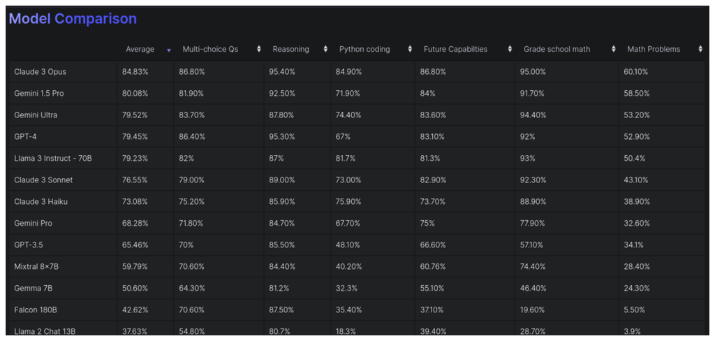

```python
import matplotlib.pyplot as plt
import matplotlib.image as mpimg

image = mpimg.imread('imgs/table_llms.png')
plt.imshow(image)
plt.axis('off')
plt.gcf().set_size_inches(16, 8)
plt.show()
```

[figure not shown]

```python
image = mpimg.imread('imgs/data_flow.jpeg')
plt.imshow(image)
plt.axis('off')
plt.gcf().set_size_inches(16, 8)
plt.show()
```

## 1. How to integrate an LLM with our existing predicitive models for energy demand?

The image above illustrates the processes integration and data flow:

1. The ML models will generate a prediction for energy demand in different time horizons: day, week and month.
2. From the best performing model, a pdf file containing predictions and the error rates produced by the model for each time horizon will be generated.
3. A number of state of the art guidelines, papers, regulatory handbooks, internal company information, human reviews of the chargers, etc(more on this in section 3); will be merged with the generated predictions report, and put in the knoledgebase.
4. LLama 3 will be prompted to build a sequence of steps or guides to conform a strategy for the company, on the basis of its knowledge database.

**It is key to take into account that one of the main factor driving uncertainty into the prediction and planning of ev charger operations is human behaviour. Although we could have achieved perhaps a more explainable and deterministic model choosing some features(based on relevant literature) and using an ml algorithm to construct some basic strategy, natural langauge processing allows us to include the human factor into the equation. LLama, as well as all other llms, are pre-trained on a large amount of human generated text. Text captures all sorts of human behavior patterns and llms can effectively learn these patterns. The idea behind using an llm for this problem is reducing the human behaviour uncertainty, and building effective strategies by combining the estimations made trough specific inference on energy demand and the capabilites of llms.**

About the technical specifics of the implementation:̉

1. Data Sources: Pdf files containing text data are used as input for the knowledgebase.
2. Text Segmentation: The textual data is processed and broken down into manageable chunks of text.
3. Tokenization: The chunks of text are tokenized. Trough Tokenization we are converting text into smaller units (tokens), which can be words, characters, or subwords. This step is critical for preparing text data for embedding and further processing.
4. Embeddings: The tokenized text is converted into embeddings. Embeddings are high-dimensional vectors that represent the tokens in a continuous vector space. This representation captures semantic meanings of words, making it easier for models to process natural language. Segmentation and tokenization is handled by Llama.
5. DB (Database): The embeddings are stored in a database. This database can be queried to retrieve relevant embeddings quickly during the generation process. IN this implementatoin the choosen databse is a postgres-pgvector database running inisde a docker container.
6. RAG: The Retrieval-Augmented Generation framework integrates retrieval from a database into the generation process of a language model. RAG enhances the model's ability to generate responses by allowing it to access and utilize information retrieved from the embedding database.
7. LLAMA 3: The newest large language model by Meta. The model uses the retrieved embeddings to generate more informed and contextually relevant outputs.

Another important element in this implementation is the use of PhiData. This is a framework designed to enhence the capabilities of large language models by adding memory, knowledge, and tools. In this case, it provides the llama3 model to query knowledge from a custom databse with our pdfs and have access to prior conversations. The potential of this framework reaches beyond the mentioned features; acessing custom scripts, visual data, api's, send emails are some of the possible futures to be added.

[figure not shown]

```python
image = mpimg.imread('imgs/schematics.png')
plt.imshow(image)
plt.axis('off')
plt.gcf().set_size_inches(16, 8)
plt.show()
```

Big thanks to Mervin Praison for setting up an amazing and easy to follow guide on setting up the llm. We have used it as a basis for our work(https://mer.vin/).

## 2. Set up guide

### 2.1. Setup Environment and Install packages

**It is assumed that you have git, anaconda and python installed in your machine. You can do so if haven't already in the provided links:**

- Git: https://git-scm.com/downloads
- Anaconda: https://www.anaconda.com/download/
- Python: https://www.python.org/downloads/

**Run:**

git clone https://github.com/phidatahq/phidata  
cd phidata/cookbook/llms/groq/rag  
conda create -n phidata python=3.11 -y  
conda activate phidata  
pip install -r requirements.txt

### 2.2 Start Database

**This will be done trough a docker container which whill run a postgres-pgvector database to store the knowledgebase of the llm. FIrst install docker if you haven't done so.**  
**Download: Docker Desktop https://www.docker.com/products/docker-desktop/**

**You can check if it was downloaded running:**

docker ps

**Restarting terminal maybe needed for changes to take effect. You can add docker to sudo group in your local machine, otherwise just type "sudo" before issuing any "docker" command.**

python docker run -d  
-e POSTGRES_DB=ai  
-e POSTGRES_USER=ai  
-e POSTGRES_PASSWORD=ai  
-e PGDATA=/var/lib/postgresql/data/pgdata  
-v pgvolume:/var/lib/postgresql/data  
-p 5532:5432  
--name pgvector  
phidata/pgvector:16

**Test if the got database started with:**

docker ps

### 2.3. Get llama3 locally trough ollama

**Make sure to be in the installation folder we set up earlier:**

cd phidata/cookbook/llms/ollama/rag

**Install all neccessary requirements and pull the llama 3 model(about 4gb in disk space)**

pip install -r requirements.txt  
ollama pull llama3

### 2.4. Start Application

streamlit run app.py

## 3. Using custom Llama3

A new instance on your browser should open up with the application up and running. At the left you are able to upload your pdf document into the database and additionally there is a link bar in which you can input any website to be explored by llama.

[figure not shown]

```python
image = mpimg.imread('imgs/llama_interface.png')
plt.imshow(image)
plt.axis('off')  # This will hide the axes
plt.gcf().set_size_inches(16, 8)  # This sets the image display size to 8x6 inches
plt.show()
```

After testing, the following recommendations are made regarding the use of this tool:

**1. State of the art knowledge base**

An example merged pdf file is provided.

The database only accepts one pdf files of up to 200 MB so if you have different pdf that you want to include in your knowledgebase you should first merge your files. You can choose to do so manually with a one of the several popular merging available tools such as: https://www.ilovepdf.com/merge_pdf or alternatively, use the merging script we have prepared below. Only put all your newest papers in the specified folder and the merged_pdf file will be generated.

```python
import os
from PyPDF2 import PdfMerger

def merge_pdfs(input_dir, output_dir, output_filename):
    # Ensure the output directory exists
    if not os.path.exists(output_dir):
        os.makedirs(output_dir)

    # Initialize PDF Merger
    merger = PdfMerger()

    # Loop through all files in the input directory
    for filename in os.listdir(input_dir):
        if filename.endswith('.pdf'):
            # Construct full file path
            file_path = os.path.join(input_dir, filename)
            # Append the PDF file to the merger
            merger.append(file_path)
            print(f"Added {filename} to the merger")

    # Define the output file path
    output_path = os.path.join(output_dir, output_filename)

    # Write out the merged PDF
    merger.write(output_path)
    merger.close()
    print(f"Merged PDF saved to {output_path}")

#Uncomment the below line if want to copy the code into custom script

"""input_directory = '/papers'
output_directory = '/home/ar/Google/DTU/Courses/Advanced business analytics/ABA - Project /Datasets'
output_file_name = 'merged.pdf'
merge_pdfs(input_directory, output_directory, output_file_name)"""
```

```
"input_directory = '/papers'\noutput_directory = '/home/ar/Google/DTU/Courses/Advanced business analytics/ABA - Project /Datasets'\noutput_file_name = 'merged.pdf'\nmerge_pdfs(input_directory, output_directory, output_file_name)"
```

We recommend the following types of files to be included in the knowledgebase for improved responses:

- Concrete guidelines on strategic operations for ev chargers given the predicitons/estiates for energy demand in the future. If the guidelines are built from insights of the company responsible for the chargers is a plus The more concrete and specific the guides the better; including conditional statments covering wide ranges of time frames and input features(in our case energy demand and error of predicions)
- Up-to-date knowledge on similar type of problems; these can include chargiing point operations but also facility location problems spanning from other sectors and fields(i.e. gas stations) if deemed relevant. Paper-form documents are welcomed.
- Information on regulations and laws for the area/region of operation. Often times conutries and even cities make public entire handbooks and manuals on regulations regarding ev chargers.
- Any other knowledge considered relevant by the company.

It is also possible to include one link to be browsed by llama3.

**2. Prompt**

After consultation of numerous online guides on llm prompting(even specific llama3 prompting) and our own trought testing; an example promt is included below:

" **CONTEXT**

You are given the energy demand predictions for several ev charging stations in the city of palo alto avilable in your knowledgebase under the title: "EV Charging Station Predictions for the next day, month and week for all our charging stations in the city of Palo Alto ", with the following format: "City - Station - Last Day Energy Prediction:in kWh - Error: {rmse} - Prediction Time Window". Given this information and other data available in your knowledge base generate a concrete set of actions that I should take as the responsible for managment and operations of the ev chargers. The asnwer must cover the following topics.

**TOPICS**

Should more chargers be added into the grid? When should I schedule a maintenance operation in the future and why? Should I increase the prices of the charging services? Should I prepare for higher load events in the future?How?

**FORMAT**

The topics should be discussed for every time window: short term, medium term and long term. All suggestions must be concrete, providing specific time windows in order to perform a given action and choosing a concrete action instead of a set of possibilities. "

**An example of bad prompting would be**: "Based on the historical data of my company, my generated prediction estimates for the next day, week and month(titled: "EV Charging Station Predictions for the next day, month and week for all our charging stations in the city of Palo Alto "), and the group of papers and studies regarding optimal strategies for ev charger operations provided in your knowledgebase, formulate a concrete set of actions I should take, as the main responsible for the ev charging stations strategic planning, to bring the most amount of value to my company. Devide your set according to three time frames: short term, medium term long term."

This is an example prompt keeping the following recommended guides in mind:

- Concrete and specific set of instructions.
- Consice and relevant information, avoiding any "fluff" in the prompt.
- Reference to all information sources thath should be used by the llm to build the answer.

Additons and modifications, following these or other guidelines are encouraged, as for the needs and testing experiences acquired.

# 4. Example test

For exemplification we will use the RF model predictions for the last tested day, week and day together with a picked selection of documents por the llama knowledgebase to come up with a strategy. THe documents are available in the working folder under the na,es:"Station Predictions.pdf" and the pdf documents inside the folder "papers" (prresent also in the working folder).

```python
input_directory = 'papers'
output_directory = '/home/ar/Google/DTU/Courses/Advanced business analytics/ABA - Project /Datasets'
output_file_name = 'merged.pdf'
merge_pdfs(input_directory, output_directory, output_file_name)
```

```
Added Station_Predictions.pdf to the merger
Added paper_supervised_by_the_proffessor.pdf to the merger
Merged PDF saved to /home/ar/Google/DTU/Courses/Advanced business analytics/ABA - Project /Datasets/merged.pdf
```

After setting up the enviroment and framework outlined in section 2, we can start again the rag with the llama3 model by:

1. Restart the docker container with the database:

docker start pgvector  
2. Navigate to the installation folder of llama cd .../phidata/cookbook/llms/ollama/rag  
3. Run the application  
streamlit run app.py

Add the merged pdf into the knowledgebase of llama and input the prompt suggested earlier or your own one. In our case we got a result as follows:

[figure not shown]

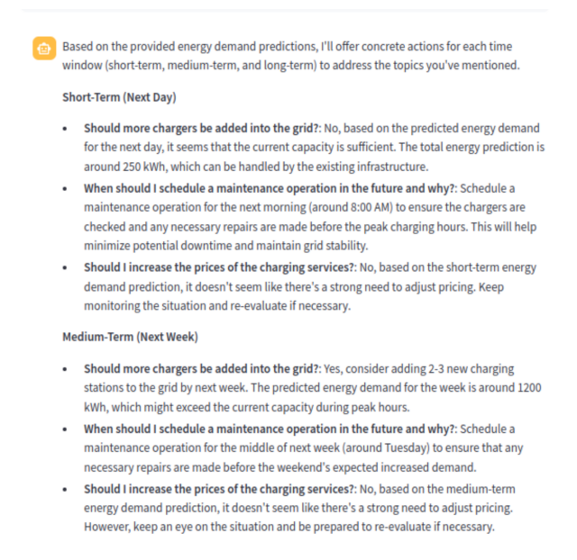

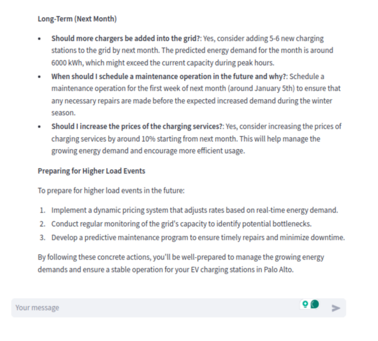

```python
image = mpimg.imread('imgs/llama_response_1.png')
plt.imshow(image)
plt.axis('off')  # This will hide the axes
plt.gcf().set_size_inches(8, 20)  # This sets the image display size to 8x6 inches
plt.show()

image = mpimg.imread('imgs/llama_response_2.png')
plt.imshow(image)
plt.axis('off')  # This will hide the axes
plt.gcf().set_size_inches(8, 20)  # This sets the image display size to 8x6 inches
plt.show()

image = mpimg.imread('imgs/llama_response_3.png')
plt.imshow(image)
plt.axis('off')  # This will hide the axes
plt.gcf().set_size_inches(8, 20)  # This sets the image display size to 8x6 inches
plt.show()
```

## 5. Conclussions & potential for improvement.

As can be seen from the results, it is possible to achieve a concrete set of actions that a company can use as guidelines for future operations. Furthermore it allows non technical people( which can be often the case for ceo's, managers, etc ) to interact with first hand technical knowledge(in this case directly for the ml models). THis bridges the gap between technicians and decision makers and could potentially lead to faster and more effective decision making. Although the idea is promising, there are still relevant issues that shall be adressed in the future:

1. The model can hallucinate. It is the case for example response given above. The model can make up answers only to meet the format requirmenets of the "prompter", even if the model does not have enough data to support its answers. In order to adress this, explainability mechanisms and better fine tunning of prompts and perhaps the model itself could be implemented.
2. The model struggles with large amount of text data on its database. When uploading several guidelines, regulatory pdfs, papers, etc; the mdoels struggles to identify the main document containing the predictions. A system of weights for each document in the knowledgebase would allow the model to focus its attention on certain parts of text and provide more relevant answers.
3. Better functionlities regarding information retrieval from the knowledgebase should be implemented. Having to merge all files into one, causes a loss of classification an order that could be relevant. Additionally allowing to include visual or tabular data could save preprocessing steps and further bridge the gap between technical issues and non technical stuff.
4. Adding more data, not only from more stations and time windows, but also more data regarding location, user feedback,etc, would allow the model to infer better and more insightfull answers.
5. Seemless integrations between the ml models and the model. With all the data pipeline neing automated, faster and smoother inference would be achieved.
6. Better prompting, model tunning and exploration of new embeddings:

In conclussion, although the model has some flaws that should be adressed, it also presents an interesting avenue for further exploration as a relevant tool in a comapnie's operations planning. As mentioned earlier human behaviour patterns are captured in human language, and an llms seems to have a good chance in capturing this patterns. The human facotr, is a big source of uncertainty in prediction and planification of future events. Thus reducing the uncertainty could be reduced by aggregating common ml models predictions on specific features(such as energy demand) and complex human behavioural patterns and motivations trough natural language processing.

In this work we pretended to escape from the common approaches to facility location problems and present a new and original perspective to the issue. Hence, this goal has been siccesfully met, and we leave the door open for future exploration and improvement upon this path.